# ---------- Amirmohammad Khosravi Esfezar ----------

# ------------------------ S.N.: 810198386 ------------------------

# ------------------------- AI_CA5 Phase2 -------------------------

**In this project we are going to train a neural network model with several hyper parameters which predicts type of animal in given pictures. Then we will find the best training and do the prediction on test data.**

In the code below we extract the dataset file and save it in our google drive.

```python
from google.colab import drive
drive.mount('/content/drive')
import zipfile
zip_ref = zipfile.ZipFile("/content/drive/MyDrive/dataset.zip", 'r')
zip_ref.extractall("/tmp")
zip_ref.close()
```

```python
from google.colab import drive
import numpy as np
import pandas as pd
import matplotlib.pyplot as plt
import os
import tensorflow
from tensorflow import keras
from tensorflow.keras import *
import tensorflow_datasets
from PIL import Image
from tensorflow.keras.utils import *
from keras.models import Sequential
from keras.layers import Dense
import matplotlib.image as mpimg
import matplotlib.pyplot as plt
import numpy
from tensorflow.keras.layers.experimental.preprocessing import Rescaling
from keras.models import Sequential,load_model
from keras.layers import Dense, Dropout
from keras import backend as K
from keras.wrappers.scikit_learn import KerasClassifier
import keras.backend as K
import random
from sklearn.metrics import classification_report
import keras
from keras.models import Sequential
from keras.layers import Dense
from tensorflow.keras import layers
from tensorflow.keras import regularizers
```

# Phase one: Preprocessing

Here we delete files which are not .jpg in both train and test folders (we have files which are .JPG , .jpeg or .gif). Then we iterate over all files and save their address in a list called imgPaths. We also save the categories of images in a list called imgCategs. At the end we make a dataframe called imgPathDf which contains paths of images and thier categories.

```python
imgCategsCounts = {
     "elk": 0,
     "bald_eagle": 0,
     "raven": 0,
     "racoon": 0
}

for imgCateg in imgCategsCounts.keys():
  for file in [file for file in os.listdir("/tmp/dataset/train/" + str(imgCateg)) if not file.endswith(".jpg")]:
      filePath = os.path.join("/tmp/dataset/train/" + imgCateg, file)
      os.remove(filePath)
  for file in [file for file in os.listdir("/tmp/dataset/test/" + str(imgCateg)) if not file.endswith(".jpg")]:
      filePath = os.path.join("/tmp/dataset/test/" + imgCateg, file)
      os.remove(filePath)

imgPathes = list()
imgCategs = list()

for imgCateg in imgCategsCounts.keys():
  for img in os.listdir('/tmp/dataset/train/' + str(imgCateg)):
    imgPathes.append(os.path.join('/tmp/dataset/train/' + str(imgCateg), img))
    imgCategs.append(imgCateg)
    imgCategsCounts[imgCateg] += 1

for imgCateg in imgCategsCounts.keys():
  print(imgCateg, ' counts: ', imgCategsCounts[imgCateg])
imgPathsDf = pd.DataFrame({
        'imgPathes' : imgPathes,
        'imgCategs' : imgCategs
    })
```

```
elk  counts:  435
bald_eagle  counts:  481
raven  counts:  410
racoon  counts:  456
```

In the following code we do the same thing for images in folder test.

```python
testImgPathes = list()
testImgCategs = list()

for imgCateg in imgCategsCounts.keys():
  for img in os.listdir('/tmp/dataset/test/' + str(imgCateg)):
    testImgPathes.append(os.path.join('/tmp/dataset/test/' + str(imgCateg), img))
    testImgCategs.append(imgCateg)
    imgCategsCounts[imgCateg] += 1

for imgCateg in imgCategsCounts.keys():
  print(imgCateg, ' counts: ', imgCategsCounts[imgCateg])
testImgPathsDf = pd.DataFrame({
        'imgPathes' : testImgPathes,
        'imgCategs' : testImgCategs
    })
```

```
elk  counts:  619
bald_eagle  counts:  686
raven  counts:  590
racoon  counts:  651
```

```python
print('Number of read images: ', len(imgPathes))
print('Number of categories: ', len(list(imgCategsCounts.keys())))
```

```
Number of read images:  1782
Number of categories:  4
```

```python
imgPathsDf
```

|  | imgPathes | imgCategs |
| --- | --- | --- |
| 0 | /tmp/dataset/train/elk/8aa0609a80a508e246.jpg | elk |
| 1 | /tmp/dataset/train/elk/a06d6e20e26ec49b43.jpg | elk |
| 2 | /tmp/dataset/train/elk/17fea56b35e6e6d04d.jpg | elk |
| 3 | /tmp/dataset/train/elk/d44f3b89e107d018ac.jpg | elk |
| 4 | /tmp/dataset/train/elk/10b378f0160f780125.jpg | elk |
| ... | ... | ... |
| 1777 | /tmp/dataset/train/racoon/ac20534b48e9c2b455.jpg | racoon |
| 1778 | /tmp/dataset/train/racoon/bae73e6799003a673a.jpg | racoon |
| 1779 | /tmp/dataset/train/racoon/9f1eb31c3ed65585dc.jpg | racoon |
| 1780 | /tmp/dataset/train/racoon/e4bebe600167a87dd0.jpg | racoon |
| 1781 | /tmp/dataset/train/racoon/4069be3809537b0d2a.jpg | racoon |

1782 rows × 2 columns

```
<BarContainer object of 4 artists>
```

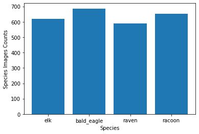

```python
plt.xlabel('Species')
plt.ylabel('Species Images Counts')
plt.bar(list(imgCategsCounts.keys()), list(imgCategsCounts.values()), align='center')
```

Here we show a random image of each species.

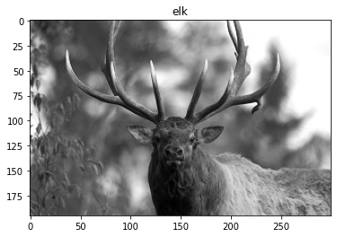

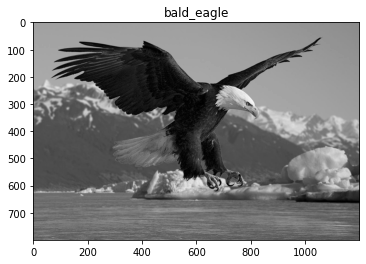

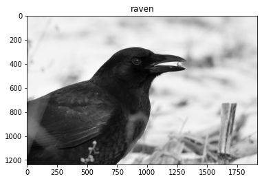

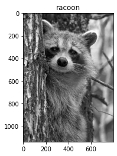

```python
for imgCateg in imgCategsCounts.keys():
  allCategImagePathes = [file for file in os.listdir("/tmp/dataset/train/" + str(imgCateg))]
  randomNumber = random.randrange(0, len(allCategImagePathes))
  image = Image.open(os.path.join('/tmp/dataset/train/' + str(imgCateg), allCategImagePathes[randomNumber])).convert('L')
  fig = plt.figure()
  plt.imshow(image, cmap='gray')
  plt.title(imgCateg)
  plt.show()
```

In the folloing cell we make our main data frames which are ready for training using some methods like ImageDataGenerator and flow_from_dataframe. These methods also scale the images and set the batch size. Here we split images in train folder into two subset called trainSet and validationSet. Later we will train our model on trainSet and try to optimize it by testing it on validationSet (which is actually our test set of data)

```python
dataGenrator = preprocessing.image.ImageDataGenerator(
    rescale = 1/255.0,
    validation_split = 0.2
)

trainSet = dataGenrator.flow_from_dataframe(
    dataframe = imgPathsDf,
    x_col = 'imgPathes',
    y_col = 'imgCategs',
    target_size = (100, 100),
    color_mode = 'grayscale',
    batch_size = 32,
    class_mode = 'categorical',
    subset = 'training',
    shuffle = True
)

validationSet = dataGenrator.flow_from_dataframe(
    dataframe = imgPathsDf,
    x_col = 'imgPathes',
    y_col = 'imgCategs',
    target_size = (100, 100),
    color_mode = 'grayscale',
    batch_size = 32,
    class_mode = 'categorical',
    subset = 'validation',
    shuffle = True
)

allTrainSet = dataGenrator.flow_from_dataframe(
    dataframe = imgPathsDf,
    x_col = 'imgPathes',
    y_col = 'imgCategs',
    target_size = (100, 100),
    color_mode = 'grayscale',
    batch_size = 32,
    class_mode = 'categorical',
    shuffle = False
)
```

```
Found 1426 validated image filenames belonging to 4 classes.
Found 356 validated image filenames belonging to 4 classes.
Found 1782 validated image filenames belonging to 4 classes.
```

Here we do the same thing for images in test folder. we save them in a data frame called allTestSet.

```python
allTestSet = dataGenrator.flow_from_dataframe(
    dataframe = testImgPathsDf,
    x_col = 'imgPathes',
    y_col = 'imgCategs',
    target_size = (100, 100),
    color_mode = 'grayscale',
    batch_size = 32,
    class_mode = 'categorical',
    shuffle = False
)
```

```
Found 764 validated image filenames belonging to 4 classes.
```

**One hot encoding:** In the following cell we do one hot encoding on the second column of data frame (on categories).

Using this technique normal sentences can be represented as vectors. This vector is made based on the vocabulary size and the encoding schema. Numerical operations can be performed on this vector form.

Applications of One-hot encoding:

Neural networks can tell us if an input image is of a cat or a dog. Since the neural network only uses numbers, it can’t output the words “cat” or “dog”. Instead, it uses one-hot encoding to represent is prediction in a semantic manner.

```python
for i in range(len(list(imgCategsCounts.keys()))):
  row = [0] * len(list(imgCategsCounts.keys()))
  row[i] = 1
  imgPathsDf['imgCategs'] = imgPathsDf['imgCategs'].replace([list(imgCategsCounts.keys())[i]], str(row))
```

```python
imgPathsDf
```

|  | imgPathes | imgCategs |
| --- | --- | --- |
| 0 | /tmp/dataset/train/elk/8aa0609a80a508e246.jpg | [1, 0, 0, 0] |
| 1 | /tmp/dataset/train/elk/a06d6e20e26ec49b43.jpg | [1, 0, 0, 0] |
| 2 | /tmp/dataset/train/elk/17fea56b35e6e6d04d.jpg | [1, 0, 0, 0] |
| 3 | /tmp/dataset/train/elk/d44f3b89e107d018ac.jpg | [1, 0, 0, 0] |
| 4 | /tmp/dataset/train/elk/10b378f0160f780125.jpg | [1, 0, 0, 0] |
| ... | ... | ... |
| 1777 | /tmp/dataset/train/racoon/ac20534b48e9c2b455.jpg | [0, 0, 0, 1] |
| 1778 | /tmp/dataset/train/racoon/bae73e6799003a673a.jpg | [0, 0, 0, 1] |
| 1779 | /tmp/dataset/train/racoon/9f1eb31c3ed65585dc.jpg | [0, 0, 0, 1] |
| 1780 | /tmp/dataset/train/racoon/e4bebe600167a87dd0.jpg | [0, 0, 0, 1] |
| 1781 | /tmp/dataset/train/racoon/4069be3809537b0d2a.jpg | [0, 0, 0, 1] |

1782 rows × 2 columns

# Phase two: Desiging Neural Network

We train our first model with 3 layers, each with 1024, 512 and 4 neurons. The learning rate is 0.01 and activation functions are relu (except for the last layer whish is softmax). After training our model on trainSet we validate it by applying it on the validationSet. The results are as follows.

```python
# FIRST MODEL

input = layers.Input(shape = (100, 100, 1))
output = layers.Flatten()(input)
output = layers.Dense(1024, activation = "relu")(output)
output = layers.Dense(512, activation = "relu")(output)
output = layers.Dense(4, activation = "softmax")(output)

model = models.Model(inputs = input, outputs = output)
model.compile(optimizer=optimizers.SGD(learning_rate=0.01), loss = 'categorical_crossentropy', metrics = 'accuracy')

model.summary()

history = model.fit(trainSet, validation_data=validationSet, epochs = 10)
```

```
Model: "model"
_________________________________________________________________
 Layer (type)                Output Shape              Param #
=================================================================
 input_1 (InputLayer)        [(None, 100, 100, 1)]     0

 flatten (Flatten)           (None, 10000)             0

 dense (Dense)               (None, 1024)              10241024

 dense_1 (Dense)             (None, 512)               524800

 dense_2 (Dense)             (None, 4)                 2052

=================================================================
Total params: 10,767,876
Trainable params: 10,767,876
Non-trainable params: 0
_________________________________________________________________
```

```python
trainPrediction = model.predict(allTrainSet)
predArgmax = np.argmax(trainPrediction, axis = 1)
print(classification_report(np.array(allTrainSet.classes), np.array(predArgmax), target_names = ['bald_eagle', 'elk', 'racoon', 'raven']))

testPrediction = model.predict(allTestSet)
predArgmax = np.argmax(testPrediction, axis = 1)
print(classification_report(np.array(allTestSet.classes), np.array(predArgmax), target_names = ['bald_eagle', 'elk', 'racoon', 'raven']))
```

```
              precision    recall  f1-score   support

  bald_eagle       0.68      0.71      0.70       481
         elk       0.00      0.00      0.00       435
      racoon       0.48      0.96      0.64       456
       raven       0.80      0.69      0.74       410

    accuracy                           0.60      1782
   macro avg       0.49      0.59      0.52      1782
weighted avg       0.49      0.60      0.52      1782

              precision    recall  f1-score   support

  bald_eagle       0.61      0.56      0.59       205
         elk       0.00      0.00      0.00       184
      racoon       0.42      0.92      0.58       195
       raven       0.67      0.57      0.61       180

    accuracy                           0.52       764
   macro avg       0.43      0.51      0.44       764
weighted avg       0.43      0.52      0.45       764
```

**--> As we can see all parameters are low and the accuracy is 0.52 too which is not good. This result is actually the best we can get with these hyper parameters. We will continue with these results and later we will get better f1-scores and higher accuracy.**

Here we plot and show how accuracy changed over different epoches.

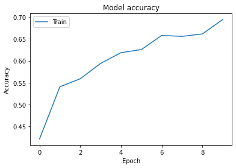

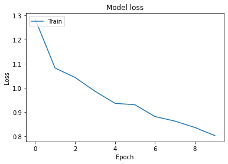

```python
# Plot training & validation accuracy values
plt.plot(history.history['accuracy'])
plt.title('Model accuracy')
plt.ylabel('Accuracy')
plt.xlabel('Epoch')
plt.legend(['Train', 'Test'], loc='upper left')
plt.show()
# Plot training & validation loss values
plt.plot(history.history['loss'])
plt.title('Model loss')
plt.ylabel('Loss')
plt.xlabel('Epoch')
plt.legend(['Train', 'Test'], loc='upper left')
plt.show()
```

To find a better model we set activation function leaky_relu and train the model again. As we can see we get worse results.

```python
input = layers.Input(shape = (100, 100, 1))
output = layers.Flatten()(input)
output = layers.Dense(1024, activation = "leaky_relu")(output)
output = layers.Dense(512, activation = "leaky_relu")(output)
output = layers.Dense(4, activation = "softmax")(output)

model = models.Model(inputs = input, outputs = output)
model.compile(optimizer=optimizers.SGD(learning_rate=0.01), loss = 'categorical_crossentropy', metrics = 'accuracy')

model.summary()

history = model.fit(trainSet, validation_data=validationSet, epochs = 10)
```

```
Model: "model_1"
_________________________________________________________________
 Layer (type)                Output Shape              Param #
=================================================================
 input_2 (InputLayer)        [(None, 100, 100, 1)]     0

 flatten_1 (Flatten)         (None, 10000)             0

 dense_3 (Dense)             (None, 1024)              10241024

 dense_4 (Dense)             (None, 512)               524800

 dense_5 (Dense)             (None, 4)                 2052

=================================================================
Total params: 10,767,876
Trainable params: 10,767,876
Non-trainable params: 0
_________________________________________________________________
```

```python
trainPrediction = model.predict(allTrainSet)
predArgmax = np.argmax(trainPrediction, axis = 1)
print(classification_report(np.array(allTrainSet.classes), np.array(predArgmax), target_names = ['bald_eagle', 'elk', 'racoon', 'raven']))

testPrediction = model.predict(allTestSet)
predArgmax = np.argmax(testPrediction, axis = 1)
print(classification_report(np.array(allTestSet.classes), np.array(predArgmax), target_names = ['bald_eagle', 'elk', 'racoon', 'raven']))
```

```
              precision    recall  f1-score   support

  bald_eagle       0.82      0.31      0.45       481
         elk       0.00      0.00      0.00       435
      racoon       0.44      0.90      0.59       456
       raven       0.52      0.85      0.65       410

    accuracy                           0.51      1782
   macro avg       0.44      0.51      0.42      1782
weighted avg       0.45      0.51      0.42      1782

              precision    recall  f1-score   support

  bald_eagle       0.67      0.23      0.34       205
         elk       0.00      0.00      0.00       184
      racoon       0.39      0.81      0.52       195
       raven       0.49      0.78      0.60       180

    accuracy                           0.45       764
   macro avg       0.39      0.45      0.37       764
weighted avg       0.39      0.45      0.37       764
```

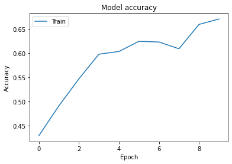

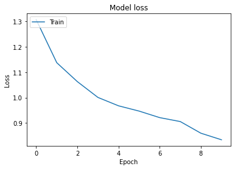

```python
# Plot training & validation accuracy values
plt.plot(history.history['accuracy'])
plt.title('Model accuracy')
plt.ylabel('Accuracy')
plt.xlabel('Epoch')
plt.legend(['Train', 'Test'], loc='upper left')
plt.show()
# Plot training & validation loss values
plt.plot(history.history['loss'])
plt.title('Model loss')
plt.ylabel('Loss')
plt.xlabel('Epoch')
plt.legend(['Train', 'Test'], loc='upper left')
plt.show()
```

# Phase three: Classifying Data

We choosed the model with three layers and relu activation function.

# Part One: Optimizers Impacts

**What is Momentum?**

Momentum takes past gradients into account to smooth out the steps of gradient descent. It can be applied with batch gradient descent, mini-batch gradient descent or stochastic gradient descent.

**Why using Momentum?**

momentum optimizer is faster and better at optimizing the model. Momentum is an easy and quick way to improve upon standard Stochastic Gradient Descent for optimizing Neural Network models. It also increase accuracy.

**--> Testing with Momentum = 0.9:**

```python
input = layers.Input(shape = (100, 100, 1))
output = layers.Flatten()(input)
output = layers.Dense(1024, activation = "relu")(output)
output = layers.Dense(512, activation = "relu")(output)
output = layers.Dense(4, activation = "softmax")(output)

model = models.Model(inputs = input, outputs = output)
model.compile(optimizer=optimizers.SGD(learning_rate=0.01, momentum=0.9), loss = 'categorical_crossentropy', metrics = 'accuracy')

model.summary()

history = model.fit(trainSet, validation_data=validationSet, epochs = 10)
```

```
Model: "model_3"
_________________________________________________________________
 Layer (type)                Output Shape              Param #
=================================================================
 input_4 (InputLayer)        [(None, 100, 100, 1)]     0

 flatten_3 (Flatten)         (None, 10000)             0

 dense_9 (Dense)             (None, 1024)              10241024

 dense_10 (Dense)            (None, 512)               524800

 dense_11 (Dense)            (None, 4)                 2052

=================================================================
Total params: 10,767,876
Trainable params: 10,767,876
Non-trainable params: 0
_________________________________________________________________
```

```python
trainPrediction = model.predict(allTrainSet)
predArgmax = np.argmax(trainPrediction, axis = 1)
print(classification_report(np.array(allTrainSet.classes), np.array(predArgmax), target_names = ['bald_eagle', 'elk', 'racoon', 'raven']))
```

```
              precision    recall  f1-score   support

  bald_eagle       0.43      0.94      0.59       481
         elk       0.00      0.00      0.00       435
      racoon       0.61      0.67      0.64       456
       raven       0.87      0.47      0.61       410

    accuracy                           0.53      1782
   macro avg       0.48      0.52      0.46      1782
weighted avg       0.47      0.53      0.46      1782
```

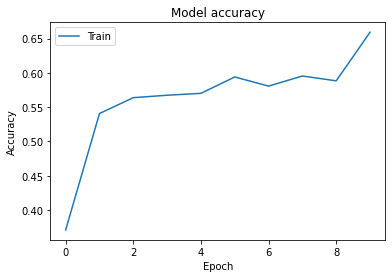

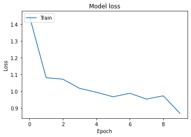

```python
# Plot training & validation accuracy values
plt.plot(history.history['accuracy'])
plt.title('Model accuracy')
plt.ylabel('Accuracy')
plt.xlabel('Epoch')
plt.legend(['Train', 'Test'], loc='upper left')
plt.show()
# Plot training & validation loss values
plt.plot(history.history['loss'])
plt.title('Model loss')
plt.ylabel('Loss')
plt.xlabel('Epoch')
plt.legend(['Train', 'Test'], loc='upper left')
plt.show()
```

**--> Testing with Momentum = 0.5**

```python
input = layers.Input(shape = (100, 100, 1))
output = layers.Flatten()(input)
output = layers.Dense(1024, activation = "relu")(output)
output = layers.Dense(512, activation = "relu")(output)
output = layers.Dense(4, activation = "softmax")(output)

model = models.Model(inputs = input, outputs = output)
model.compile(optimizer=optimizers.SGD(learning_rate=0.01, momentum=0.5), loss = 'categorical_crossentropy', metrics = 'accuracy')

model.summary()

history = model.fit(trainSet, validation_data=validationSet, epochs = 10)
```

```
Model: "model_5"
_________________________________________________________________
 Layer (type)                Output Shape              Param #
=================================================================
 input_6 (InputLayer)        [(None, 100, 100, 1)]     0

 flatten_5 (Flatten)         (None, 10000)             0

 dense_15 (Dense)            (None, 1024)              10241024

 dense_16 (Dense)            (None, 512)               524800

 dense_17 (Dense)            (None, 4)                 2052

=================================================================
Total params: 10,767,876
Trainable params: 10,767,876
Non-trainable params: 0
_________________________________________________________________
```

```python
trainPrediction = model.predict(allTrainSet)
predArgmax = np.argmax(trainPrediction, axis = 1)
print(classification_report(np.array(allTrainSet.classes), np.array(predArgmax), target_names = ['bald_eagle', 'elk', 'racoon', 'raven']))
```

```
              precision    recall  f1-score   support

  bald_eagle       0.75      0.68      0.71       481
         elk       1.00      0.07      0.13       435
      racoon       0.61      0.89      0.72       456
       raven       0.58      0.91      0.71       410

    accuracy                           0.64      1782
   macro avg       0.73      0.64      0.57      1782
weighted avg       0.74      0.64      0.57      1782
```

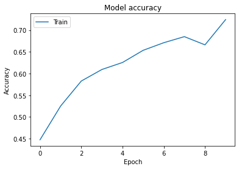

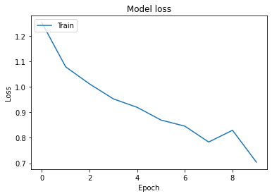

```python
# Plot training & validation accuracy values
plt.plot(history.history['accuracy'])
plt.title('Model accuracy')
plt.ylabel('Accuracy')
plt.xlabel('Epoch')
plt.legend(['Train', 'Test'], loc='upper left')
plt.show()
# Plot training & validation loss values
plt.plot(history.history['loss'])
plt.title('Model loss')
plt.ylabel('Loss')
plt.xlabel('Epoch')
plt.legend(['Train', 'Test'], loc='upper left')
plt.show()
```

**As we can see we get better results wiht Momentum = 0.5 than 0.9 Because 0.9 is a bit large for Momentum and it causes worst results (we explained it's reason later later)**

**Does increasing Momentum always help?**

No. If we increase Momentum too much it will take more past gradients into account which is not good. Also a large Momentum may cause random behavior and stop the learning process, on the other hand very small values wont cause changes.

**--> Using Adam Optimizer:**

```python
input = layers.Input(shape = (100, 100, 1))
output = layers.Flatten()(input)
output = layers.Dense(1024, activation = "relu")(output)
output = layers.Dense(512, activation = "relu")(output)
output = layers.Dense(4, activation = "softmax")(output)

model = models.Model(inputs = input, outputs = output)
model.compile(optimizer=optimizers.Adam(learning_rate=0.001), loss = 'categorical_crossentropy', metrics = 'accuracy')

model.summary()

history = model.fit(trainSet, validation_data=validationSet, epochs = 10)
```

```
Model: "model_14"
_________________________________________________________________
 Layer (type)                Output Shape              Param #
=================================================================
 input_15 (InputLayer)       [(None, 100, 100, 1)]     0

 flatten_14 (Flatten)        (None, 10000)             0

 dense_42 (Dense)            (None, 1024)              10241024

 dense_43 (Dense)            (None, 512)               524800

 dense_44 (Dense)            (None, 4)                 2052

=================================================================
Total params: 10,767,876
Trainable params: 10,767,876
Non-trainable params: 0
_________________________________________________________________
```

```python
trainPrediction = model.predict(allTrainSet)
predArgmax = np.argmax(trainPrediction, axis = 1)
print(classification_report(np.array(allTrainSet.classes), np.array(predArgmax), target_names = ['bald_eagle', 'elk', 'racoon', 'raven']))
```

```
              precision    recall  f1-score   support

  bald_eagle       0.75      0.52      0.62       481
         elk       1.00      0.00      0.00       435
      racoon       0.42      0.94      0.58       456
       raven       0.70      0.73      0.71       410

    accuracy                           0.55      1782
   macro avg       0.72      0.55      0.48      1782
weighted avg       0.71      0.55      0.48      1782
```

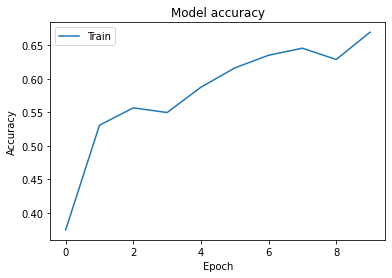

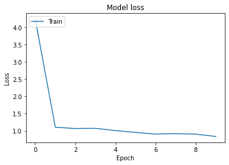

```python
# Plot training & validation accuracy values
plt.plot(history.history['accuracy'])
plt.title('Model accuracy')
plt.ylabel('Accuracy')
plt.xlabel('Epoch')
plt.legend(['Train', 'Test'], loc='upper left')
plt.show()
# Plot training & validation loss values
plt.plot(history.history['loss'])
plt.title('Model loss')
plt.ylabel('Loss')
plt.xlabel('Epoch')
plt.legend(['Train', 'Test'], loc='upper left')
plt.show()
```

**-->** As we can see using adams optimizer we dont get better results but loss decreases faster which is good.

# Part two: Epoch Impact

**--> Training data with 20 epochs:**

```python
input = layers.Input(shape = (100, 100, 1))
output = layers.Flatten()(input)
output = layers.Dense(1024, activation = "relu")(output)
output = layers.Dense(512, activation = "relu")(output)
output = layers.Dense(4, activation = "softmax")(output)

model = models.Model(inputs = input, outputs = output)
model.compile(optimizer=optimizers.SGD(learning_rate=0.01, momentum=0.5), loss = 'categorical_crossentropy', metrics = 'accuracy')

model.summary()

history = model.fit(trainSet, validation_data=validationSet, epochs = 20)
```

```
Model: "model_11"
_________________________________________________________________
 Layer (type)                Output Shape              Param #
=================================================================
 input_12 (InputLayer)       [(None, 100, 100, 1)]     0

 flatten_11 (Flatten)        (None, 10000)             0

 dense_33 (Dense)            (None, 1024)              10241024

 dense_34 (Dense)            (None, 512)               524800

 dense_35 (Dense)            (None, 4)                 2052

=================================================================
Total params: 10,767,876
Trainable params: 10,767,876
Non-trainable params: 0
_________________________________________________________________
```

```python
trainPrediction = model.predict(allTrainSet)
predArgmax = np.argmax(trainPrediction, axis = 1)
print(classification_report(np.array(allTrainSet.classes), np.array(predArgmax), target_names = ['bald_eagle', 'elk', 'racoon', 'raven']))
```

```
              precision    recall  f1-score   support

  bald_eagle       0.76      0.93      0.83       481
         elk       0.99      0.34      0.51       435
      racoon       0.78      0.95      0.85       456
       raven       0.82      0.97      0.89       410

    accuracy                           0.80      1782
   macro avg       0.83      0.80      0.77      1782
weighted avg       0.83      0.80      0.77      1782
```

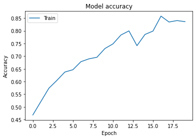

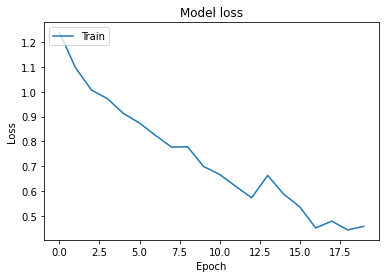

```python
# Plot training & validation accuracy values
plt.plot(history.history['accuracy'])
plt.title('Model accuracy')
plt.ylabel('Accuracy')
plt.xlabel('Epoch')
plt.legend(['Train', 'Test'], loc='upper left')
plt.show()
# Plot training & validation loss values
plt.plot(history.history['loss'])
plt.title('Model loss')
plt.ylabel('Loss')
plt.xlabel('Epoch')
plt.legend(['Train', 'Test'], loc='upper left')
plt.show()
```

**Why we use multiple epoch?**

We want to get good performance on non-training data (in practice this can be approximated with a hold-out set); usually (but not always) that takes more than one pass over the training data.

Additionally, and independent of any out-of-sample considerations, it's typical that gradient descent doesn't reach a (global or local) minimum after the first epoch. For any problem, there's no reason to believe that the number of updates required to reach a minimum happens to coincide with the number of mini-batches in your data set.

**Second answer:**

Generally whenever you want to optimize you use gradient descent. Gradient descent has a parameter called learning rate. In one iteration alone you can not guarantee that the gradient descent algorithm would converge to a local minima with the specified learning rate. That is the reason why you iterate again for the gradient descent to converge better.

Its also a good practice to change learning rates per epoch by observing the learning curves for better convergence.

**Does every model needs several epochs?** Yes

**Here we set number of epochs to 40 to cause the training overfitting.**

```python
input = layers.Input(shape = (100, 100, 1))
output = layers.Flatten()(input)
output = layers.Dense(1024, activation = "relu")(output)
output = layers.Dense(512, activation = "relu")(output)
output = layers.Dense(4, activation = "softmax")(output)

model = models.Model(inputs = input, outputs = output)
model.compile(optimizer=optimizers.SGD(learning_rate=0.01, momentum=0.5), loss = 'categorical_crossentropy', metrics = 'accuracy')

model.summary()

history = model.fit(trainSet, validation_data=validationSet, epochs = 40)
```

```
Model: "model_12"
_________________________________________________________________
 Layer (type)                Output Shape              Param #
=================================================================
 input_13 (InputLayer)       [(None, 100, 100, 1)]     0

 flatten_12 (Flatten)        (None, 10000)             0

 dense_36 (Dense)            (None, 1024)              10241024

 dense_37 (Dense)            (None, 512)               524800

 dense_38 (Dense)            (None, 4)                 2052

=================================================================
Total params: 10,767,876
Trainable params: 10,767,876
Non-trainable params: 0
_________________________________________________________________
```

```python
trainPrediction = model.predict(allTrainSet)
predArgmax = np.argmax(trainPrediction, axis = 1)
print(classification_report(np.array(allTrainSet.classes), np.array(predArgmax), target_names = ['bald_eagle', 'elk', 'racoon', 'raven']))
```

```
              precision    recall  f1-score   support

  bald_eagle       0.41      0.98      0.57       481
         elk       0.75      0.03      0.05       435
      racoon       1.00      0.03      0.05       456
       raven       0.67      0.98      0.80       410

    accuracy                           0.50      1782
   macro avg       0.71      0.50      0.37      1782
weighted avg       0.70      0.50      0.36      1782
```

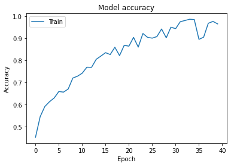

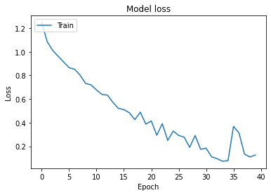

```python
# Plot training & validation accuracy values
plt.plot(history.history['accuracy'])
plt.title('Model accuracy')
plt.ylabel('Accuracy')
plt.xlabel('Epoch')
plt.legend(['Train', 'Test'], loc='upper left')
plt.show()
# Plot training & validation loss values
plt.plot(history.history['loss'])
plt.title('Model loss')
plt.ylabel('Loss')
plt.xlabel('Epoch')
plt.legend(['Train', 'Test'], loc='upper left')
plt.show()
```

As we can see after 35 epochs, the model overfits and the accuracy decreased.

Using more epoches is not always good. We have an optimal number of epoches which gives a best result, if we have more epochs the train will overfit. There are some methods that we can use to find the best number of epochs and stop training before overfitting.

# Part three: Loss Fucntion Impact

```python
input = layers.Input(shape = (100, 100, 1))
output = layers.Flatten()(input)
output = layers.Dense(1024, activation = "relu")(output)
output = layers.Dense(512, activation = "relu")(output)
output = layers.Dense(4, activation = "softmax")(output)

model = models.Model(inputs = input, outputs = output)
model.compile(optimizer=optimizers.Adam(learning_rate=0.001), loss = 'mean_squared_error', metrics = 'accuracy')

model.summary()

history = model.fit(trainSet, validation_data=validationSet, epochs = 20)
```

```
Model: "model_15"
_________________________________________________________________
 Layer (type)                Output Shape              Param #
=================================================================
 input_16 (InputLayer)       [(None, 100, 100, 1)]     0

 flatten_15 (Flatten)        (None, 10000)             0

 dense_45 (Dense)            (None, 1024)              10241024

 dense_46 (Dense)            (None, 512)               524800

 dense_47 (Dense)            (None, 4)                 2052

=================================================================
Total params: 10,767,876
Trainable params: 10,767,876
Non-trainable params: 0
_________________________________________________________________
```

```python
trainPrediction = model.predict(allTrainSet)
predArgmax = np.argmax(trainPrediction, axis = 1)
print(classification_report(np.array(allTrainSet.classes), np.array(predArgmax), target_names = ['bald_eagle', 'elk', 'racoon', 'raven']))
```

```
              precision    recall  f1-score   support

  bald_eagle       0.00      0.00      0.00       481
         elk       0.00      0.00      0.00       435
      racoon       0.26      1.00      0.41       456
       raven       0.00      0.00      0.00       410

    accuracy                           0.26      1782
   macro avg       0.06      0.25      0.10      1782
weighted avg       0.07      0.26      0.10      1782
```

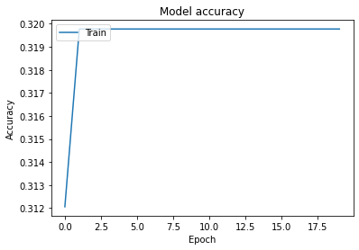

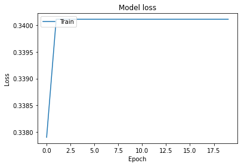

```python
# Plot training & validation accuracy values
plt.plot(history.history['accuracy'])
plt.title('Model accuracy')
plt.ylabel('Accuracy')
plt.xlabel('Epoch')
plt.legend(['Train', 'Test'], loc='upper left')
plt.show()
# Plot training & validation loss values
plt.plot(history.history['loss'])
plt.title('Model loss')
plt.ylabel('Loss')
plt.xlabel('Epoch')
plt.legend(['Train', 'Test'], loc='upper left')
plt.show()
```

**As we can see the accuracy and result in this model is very bad and worse than the previous ones.** because penalty for being wrong increases exponentially as you get closer to predicting the wrong output.

MSE is used in regression models but cross entropy is used in classification problems (what we have here).

# Part four: Regularization Impact

**--> Testing with 0.0001:**

Regularizers allow you to apply penalties on layer parameters or layer activity during optimization. These penalties are summed into the loss function that the network optimizes.

**l1:** L1 regularization effect on the neural network weight values is that it penalizes weight values that are close to 0 by making them equal to 0. Negative weight values also take a value of 0; so if a weight value is -2, under the effect of L1 regularization, it becomes 0. The general intuition with L1 regularization is that, if a weight value is close to 0 or very small, then it’s negligible when it comes to the overall performance of the model, therefore making it 0 does not affect the model’s performance and can reduce the memory capacity of the model. L1 penalizes the sum of the absolute values of the weights (|weight|)

**l2:** L2 regularization also penalizes weight values. For both small weight values and relatively large ones, L2 regularization transforms the values to a number close to 0, but not quite 0. l2 penalizes the sum of the square of the weights (weight²)

```python
input = layers.Input(shape = (100, 100, 1))
output = layers.Flatten()(input)
output = layers.Dense(1024, activation = "relu", bias_regularizer=regularizers.l2(1e-4))(output)
output = layers.Dense(512, activation = "relu", bias_regularizer=regularizers.l2(1e-4))(output)
output = layers.Dense(4, activation = "softmax")(output)

model = models.Model(inputs = input, outputs = output)
model.compile(optimizer=optimizers.SGD(learning_rate=0.01, momentum=0.5), loss = 'categorical_crossentropy', metrics = 'accuracy')
# optimizer=optimizers.Adam(learning_rate=0.001)
model.summary()

history = model.fit(trainSet, validation_data=validationSet, epochs = 20)
```

```
Model: "model_18"
_________________________________________________________________
 Layer (type)                Output Shape              Param #
=================================================================
 input_19 (InputLayer)       [(None, 100, 100, 1)]     0

 flatten_18 (Flatten)        (None, 10000)             0

 dense_54 (Dense)            (None, 1024)              10241024

 dense_55 (Dense)            (None, 512)               524800

 dense_56 (Dense)            (None, 4)                 2052

=================================================================
Total params: 10,767,876
Trainable params: 10,767,876
Non-trainable params: 0
_________________________________________________________________
```

```python
trainPrediction = model.predict(allTrainSet)
predArgmax = np.argmax(trainPrediction, axis = 1)
print(classification_report(np.array(allTrainSet.classes), np.array(predArgmax), target_names = ['bald_eagle', 'elk', 'racoon', 'raven']))
```

```
              precision    recall  f1-score   support

  bald_eagle       0.63      0.99      0.77       481
         elk       0.97      0.34      0.51       435
      racoon       0.79      0.96      0.87       456
       raven       0.95      0.74      0.83       410

    accuracy                           0.77      1782
   macro avg       0.83      0.76      0.74      1782
weighted avg       0.83      0.77      0.74      1782
```

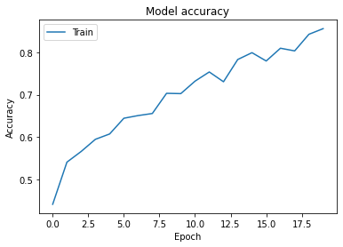

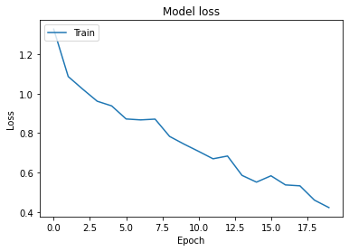

```python
# Plot training & validation accuracy values
plt.plot(history.history['accuracy'])
plt.title('Model accuracy')
plt.ylabel('Accuracy')
plt.xlabel('Epoch')
plt.legend(['Train', 'Test'], loc='upper left')
plt.show()
# Plot training & validation loss values
plt.plot(history.history['loss'])
plt.title('Model loss')
plt.ylabel('Loss')
plt.xlabel('Epoch')
plt.legend(['Train', 'Test'], loc='upper left')
plt.show()
```

```python
input = layers.Input(shape = (100, 100, 1))
output = layers.Flatten()(input)
output = layers.Dense(1024, activation = "relu", bias_regularizer=regularizers.l2(1e-4))(output)
output = layers.Dense(512, activation = "relu", bias_regularizer=regularizers.l2(1e-4))(output)
output = layers.Dense(4, activation = "softmax")(output)

model = models.Model(inputs = input, outputs = output)
model.compile(optimizer=optimizers.Adam(learning_rate=0.001), loss = 'categorical_crossentropy', metrics = 'accuracy')
model.summary()

history = model.fit(trainSet, validation_data=validationSet, epochs = 20)
```

```
Model: "model_20"
_________________________________________________________________
 Layer (type)                Output Shape              Param #
=================================================================
 input_21 (InputLayer)       [(None, 100, 100, 1)]     0

 flatten_20 (Flatten)        (None, 10000)             0

 dense_60 (Dense)            (None, 1024)              10241024

 dense_61 (Dense)            (None, 512)               524800

 dense_62 (Dense)            (None, 4)                 2052

=================================================================
Total params: 10,767,876
Trainable params: 10,767,876
Non-trainable params: 0
_________________________________________________________________
```

```python
trainPrediction = model.predict(allTrainSet)
predArgmax = np.argmax(trainPrediction, axis = 1)
print(classification_report(np.array(allTrainSet.classes), np.array(predArgmax), target_names = ['bald_eagle', 'elk', 'racoon', 'raven']))
```

```
              precision    recall  f1-score   support

  bald_eagle       0.72      0.79      0.75       481
         elk       1.00      0.00      0.01       435
      racoon       0.44      0.99      0.61       456
       raven       0.95      0.53      0.68       410

    accuracy                           0.59      1782
   macro avg       0.78      0.58      0.51      1782
weighted avg       0.77      0.59      0.52      1782
```

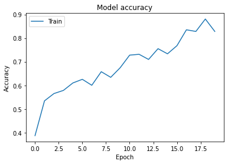

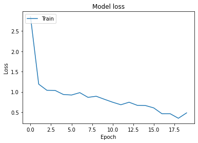

```python
# Plot training & validation accuracy values
plt.plot(history.history['accuracy'])
plt.title('Model accuracy')
plt.ylabel('Accuracy')
plt.xlabel('Epoch')
plt.legend(['Train', 'Test'], loc='upper left')
plt.show()
# Plot training & validation loss values
plt.plot(history.history['loss'])
plt.title('Model loss')
plt.ylabel('Loss')
plt.xlabel('Epoch')
plt.legend(['Train', 'Test'], loc='upper left')
plt.show()
```

**--> Testing with dropout 0.1:**

The Dropout layer randomly sets input units to 0 with a frequency of rate at each step during training time, which helps prevent overfitting. Inputs not set to 0 are scaled up by 1/(1 - rate) such that the sum over all inputs is unchanged.

dropout is a regularizer technique that reduces the odds of overfitting by dropping out neurons at random, during every epoch (or, when using a minibatch approach, during every minibatch).

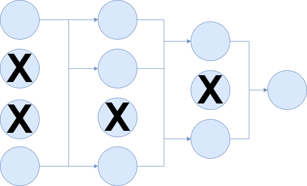

Dropping out neurons happens by attaching Bernoulli variables to the neural outputs (Srivastava et al., 2014). These variables, which take the value of 1 with probability p and 0 with 1−p, help reduce overfitting by “making the presence of other (..) units unreliable”. This way, neural networks cannot generate what Srivastava et al. call complex co-adaptations that do not generalize to unseen data.

By consequence, the occurrence of overfitting is reduced.

source: https://www.machinecurve.com/index.php/2019/12/18/how-to-use-dropout-with-keras/

```python
input = layers.Input(shape = (100, 100, 1))
output = layers.Flatten()(input)
output = layers.Dense(1024, activation = "relu")(output)
output = layers.Dropout(0.1)(output)
output = layers.Dense(512, activation = "relu")(output)
output = layers.Dropout(0.1)(output)
output = layers.Dense(4, activation = "softmax")(output)

model = models.Model(inputs = input, outputs = output)
model.compile(optimizer=optimizers.Adam(learning_rate=0.1), loss = 'categorical_crossentropy', metrics = 'accuracy')
model.summary()

history = model.fit(trainSet, validation_data=validationSet, epochs = 20)
```

```
Model: "model_22"
_________________________________________________________________
 Layer (type)                Output Shape              Param #
=================================================================
 input_24 (InputLayer)       [(None, 100, 100, 1)]     0

 flatten_23 (Flatten)        (None, 10000)             0

 dense_64 (Dense)            (None, 1024)              10241024

 dropout_3 (Dropout)         (None, 1024)              0

 dense_65 (Dense)            (None, 512)               524800

 dropout_4 (Dropout)         (None, 512)               0

 dense_66 (Dense)            (None, 4)                 2052

=================================================================
Total params: 10,767,876
Trainable params: 10,767,876
Non-trainable params: 0
_________________________________________________________________
```

[output not shown]

[output cut: 16 more lines]

[output not shown]

```python
trainPrediction = model.predict(allTrainSet)
predArgmax = np.argmax(trainPrediction, axis = 1)
print(classification_report(np.array(allTrainSet.classes), np.array(predArgmax), target_names = ['bald_eagle', 'elk', 'racoon', 'raven']))
```

[output not shown]

```python
# Plot training & validation accuracy values
plt.plot(history.history['accuracy'])
plt.title('Model accuracy')
plt.ylabel('Accuracy')
plt.xlabel('Epoch')
plt.legend(['Train', 'Test'], loc='upper left')
plt.show()
# Plot training & validation loss values
plt.plot(history.history['loss'])
plt.title('Model loss')
plt.ylabel('Loss')
plt.xlabel('Epoch')
plt.legend(['Train', 'Test'], loc='upper left')
plt.show()
```

[output not shown]

# Predicting the test data:

We saw that the best model is like below.

```python
input = layers.Input(shape = (100, 100, 1))
output = layers.Flatten()(input)
output = layers.Dense(1024, activation = "relu", bias_regularizer=regularizers.l2(1e-4))(output)
output = layers.Dense(512, activation = "relu", bias_regularizer=regularizers.l2(1e-4))(output)
output = layers.Dense(4, activation = "softmax")(output)

model = models.Model(inputs = input, outputs = output)
model.compile(optimizer=optimizers.SGD(learning_rate=0.01, momentum=0.5), loss = 'categorical_crossentropy', metrics = 'accuracy')
# optimizer=optimizers.Adam(learning_rate=0.001)
model.summary()

history = model.fit(trainSet, validation_data=validationSet, epochs = 25)
```

```
Model: "model_2"
_________________________________________________________________
 Layer (type)                Output Shape              Param #
=================================================================
 input_3 (InputLayer)        [(None, 100, 100, 1)]     0

 flatten_2 (Flatten)         (None, 10000)             0

 dense_6 (Dense)             (None, 1024)              10241024

 dense_7 (Dense)             (None, 512)               524800

 dense_8 (Dense)             (None, 4)                 2052

=================================================================
Total params: 10,767,876
Trainable params: 10,767,876
Non-trainable params: 0
_________________________________________________________________
```

```python
testPrediction = model.predict(allTestSet)
predArgmax = np.argmax(testPrediction, axis = 1)
print(classification_report(np.array(allTestSet.classes), np.array(predArgmax), target_names = ['bald_eagle', 'elk', 'racoon', 'raven']))
```

```
              precision    recall  f1-score   support

  bald_eagle       0.82      0.41      0.55       205
         elk       1.00      0.04      0.08       184
      racoon       0.42      0.95      0.58       195
       raven       0.68      0.78      0.73       180

    accuracy                           0.55       764
   macro avg       0.73      0.55      0.49       764
weighted avg       0.73      0.55      0.49       764
```

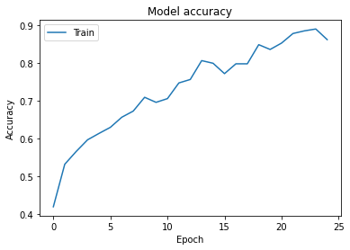

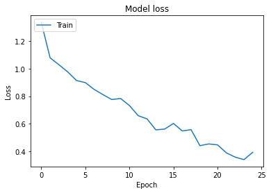

```python
# Plot training & validation accuracy values
plt.plot(history.history['accuracy'])
plt.title('Model accuracy')
plt.ylabel('Accuracy')
plt.xlabel('Epoch')
plt.legend(['Train', 'Test'], loc='upper left')
plt.show()
# Plot training & validation loss values
plt.plot(history.history['loss'])
plt.title('Model loss')
plt.ylabel('Loss')
plt.xlabel('Epoch')
plt.legend(['Train', 'Test'], loc='upper left')
plt.show()
```

# Showing 10 true and false predicted images

```python
perdsCategs = list()
for i in predArgmax:
  if i == 0:
    perdsCategs.append('bald_eagle')
  elif i == 1:
    perdsCategs.append('elk')
  elif i == 2:
    perdsCategs.append('racoon')
  else:
    perdsCategs.append('raven')

print(perdsCategs)
```

```
['racoon', 'raven', 'racoon', 'racoon', 'elk', 'elk', 'racoon', 'racoon', 'racoon', 'racoon', 'raven', 'racoon', 'racoon', 'racoon', 'raven', 'racoon', 'racoon', 'racoon', 'racoon', 'racoon', 'racoon', 'racoon', 'racoon', 'racoon', 'racoon', 'racoon', 'racoon', 'racoon', 'racoon', 'raven', 'racoon',…
```

```
Ten flase predicted
```

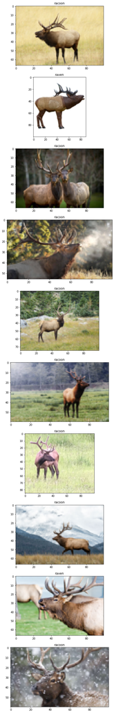

```
Ten true predicted
```

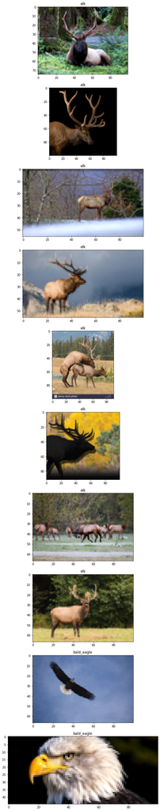

```python
print('Ten flase predicted  ')
plt.figure(figsize=(500,50))
counter = 0
for i in range(len(testImgCategs)):
  if(perdsCategs[i] != testImgCategs[i]):
    plt.subplot(10,1,counter+1)
    img = Image.open(testImgPathes[i])
    img.thumbnail((100, 100))
    plt.title(perdsCategs[i])
    plt.imshow(img)
    counter += 1
    if counter > 9:
      break
plt.show()

print('Ten true predicted  ')
plt.figure(figsize=(500,50))
counter = 0
for i in range(len(testImgCategs)):
  if(perdsCategs[i] == testImgCategs[i]):
    plt.subplot(10,1,counter+1)
    img = Image.open(testImgPathes[i])
    img.thumbnail((100, 100))
    plt.title(perdsCategs[i])
    plt.imshow(img)
    counter += 1
    if counter > 9:
      break

plt.show()
```

Some times elk look like racoons so our model make mistakes and doesnt predict truely.